# Stocks_predict_tiprank_zacks

```python
import numpy as np
import pandas as pd
import matplotlib.pyplot as plt
import seaborn as sns
sns.set()
```

```python
data = pd.read_csv('Stocks800_2020-09-16.csv')
```

```python
data
```

|  | Ticker | Company Name | Price (Q2) | Low PT | Avg PT | High PT | # Analyst | LowPT/Curr% | AvgPT/Curr% | HighPT/Curr% | ... | Positive Q2 | Neg Q2 | zacks rank | value score | growth score | momentum score | overall score | industry rank | Price(Q3) | Change% |
| --- | --- | --- | --- | --- | --- | --- | --- | --- | --- | --- | --- | --- | --- | --- | --- | --- | --- | --- | --- | --- | --- |
| 0 | ZM | Zoom Video Communications\n | 261.18 | 255.0 | 408.00 | 525.0 | 24 | -0.023662 | 0.562141 | 1.010108 | ... | 22.0 | 6.0 | 1.0 | F | A | C | D | 1.4 | 470.11 | 0.7999 |
| 1 | COOP | Mr Cooper Group | 13.40 | 14.0 | 19.83 | 26.0 | 7 | 0.044776 | 0.479851 | 0.940299 | ... | 2.0 | 0.0 | 1.0 | A | B | A | A | 2.7 | 22.32 | 0.6657 |
| 2 | FDX | FedEx | 165.14 | 100.0 | 218.23 | 300.0 | 23 | -0.394453 | 0.321485 | 0.816640 | ... | 1.0 | 0.0 | 1.0 | C | A | A | A | 41.8 | 251.52 | 0.5231 |
| 3 | BLDR | Builders Firstsource\n | 23.29 | 27.0 | 33.38 | 37.0 | 8 | 0.159296 | 0.433233 | 0.588665 | ... | 0.0 | 0.0 | 1.0 | B | A | C | A | 13.9 | 32.62 | 0.4006 |
| 4 | RH | RH | 285.03 | 380.0 | 415.11 | 450.0 | 11 | 0.333193 | 0.456373 | 0.578781 | ... | 4.0 | 1.0 | 1.0 | D | A | C | C | 12.0 | 382.62 | 0.3424 |
| ... | ... | ... | ... | ... | ... | ... | ... | ... | ... | ... | ... | ... | ... | ... | ... | ... | ... | ... | ... | ... | ... |
| 856 | ARMK | ARAMARK Holdings\n | 23.28 | 24.0 | 28.00 | 36.0 | 8 | 0.030928 | 0.202749 | 0.546392 | ... | 2.0 | 5.0 | 5.0 | D | C | F | D | 2.1 | 26.45 | 0.1362 |
| 857 | CCL | Carnival | 15.14 | 10.0 | 15.93 | 24.0 | 18 | -0.339498 | 0.052180 | 0.585205 | ... | 0.0 | 3.0 | 5.0 | B | F | D | D | 1.0 | 15.18 | 0.0026 |
| 858 | SPR | Spirit AeroSystems\n | 22.89 | 12.0 | 21.70 | 26.0 | 11 | -0.475754 | -0.051988 | 0.135867 | ... | 0.0 | 2.0 | 5.0 | B | C | F | C | 1.1 | 18.91 | -0.1739 |
| 859 | PRNB | Principia Biopharma\n | 82.75 | 100.0 | 107.57 | 130.0 | 7 | 0.208459 | 0.299940 | 0.570997 | ... | 1.0 | 2.0 | NaN | NaN | NaN | NaN | NaN | NaN | 100.50 | 0.2145 |
| 860 | CBOE | Cboe Global Markets\n | 91.65 | 88.0 | 98.20 | 115.0 | 10 | -0.039825 | 0.071468 | 0.254774 | ... | 0.0 | 0.0 | 3.0 | D | A | C | B | 2.0 | 87.74 | -0.0427 |

861 rows × 22 columns

## Data Cleaning and Pre-Processing

First off, we will look for any missing/null values in the dataset

```python
data.isnull().sum()
```

```
Ticker            0
Company Name      0
Price (Q2)        0
Low PT            0
Avg PT            0
High PT           0
# Analyst         0
LowPT/Curr%       0
AvgPT/Curr%       0
HighPT/Curr%      0
Rating            0
Pos-Neg           0
Positive Q2       5
Neg Q2            5
zacks rank        6
value score       6
growth score      6
momentum score    6
overall score     6
industry rank     1
Price(Q3)         0
Change%           0
dtype: int64
```

Since missing data is less than 1% of the data, they can be dropped without affecting the model Only rows with missing Zack's rank scores should be dropped. Positive Q2 and Neg Q2 variables can be imputed as value of "0" since these two variables are less important

```python
data[data.isna().any(axis=1)]
```

|  | Ticker | Company Name | Price (Q2) | Low PT | Avg PT | High PT | # Analyst | LowPT/Curr% | AvgPT/Curr% | HighPT/Curr% | ... | Positive Q2 | Neg Q2 | zacks rank | value score | growth score | momentum score | overall score | industry rank | Price(Q3) | Change% |
| --- | --- | --- | --- | --- | --- | --- | --- | --- | --- | --- | --- | --- | --- | --- | --- | --- | --- | --- | --- | --- | --- |
| 12 | QGEN | Qiagen | 48.56 | 46.32 | 56.64 | 71.26 | 15 | -0.046129 | 0.166392 | 0.467463 | ... | NaN | NaN | 1.0 | D | C | D | D | 1.3 | 52.26 | 0.0762 |
| 69 | CCI | Crown Castle | 168.06 | 148.00 | 179.00 | 195.00 | 9 | -0.119362 | 0.065096 | 0.160300 | ... | NaN | NaN | 3.0 | D | C | F | D | 1.1 | 166.50 | -0.0093 |
| 96 | INO | Inovio Pharmaceuticals\n | 26.19 | 8.00 | 19.00 | 36.00 | 8 | -0.694540 | -0.274532 | 0.374570 | ... | 6.0 | 6.0 | NaN | NaN | NaN | NaN | NaN | 1.3 | 11.60 | -0.5571 |
| 185 | SPOT | Spotify Technology SA\n | 289.62 | 172.00 | 270.76 | 357.00 | 25 | -0.406118 | -0.065120 | 0.232650 | ... | NaN | NaN | 3.0 | F | B | F | D | 1.5 | 242.57 | -0.1625 |
| 436 | VKTX | Viking Therapeutics\n | 6.81 | 12.00 | 15.43 | 21.00 | 9 | 0.762115 | 1.265786 | 2.083700 | ... | 0.0 | 2.0 | NaN | NaN | NaN | NaN | NaN | 1.3 | 5.82 | -0.1454 |
| 437 | BTAI | Bioxcel Therapeutics\n | 64.63 | 63.00 | 113.57 | 175.00 | 7 | -0.025220 | 0.757233 | 1.707721 | ... | 0.0 | 6.0 | NaN | NaN | NaN | NaN | NaN | 1.3 | 43.36 | -0.3291 |
| 543 | LVGO | Livongo Health | 110.56 | 70.00 | 113.20 | 150.00 | 12 | -0.366860 | 0.023878 | 0.356729 | ... | 3.0 | 10.0 | NaN | NaN | NaN | NaN | NaN | 1.4 | 140.05 | 0.2667 |
| 592 | FRC | First Republic Bank\n | 113.20 | 85.00 | 119.93 | 140.00 | 14 | -0.249117 | 0.059452 | 0.236749 | ... | NaN | NaN | 3.0 | D | F | D | F | 2.0 | 109.06 | -0.0366 |
| 642 | TEAM | Atlassian | 191.30 | 175.00 | 204.44 | 240.00 | 11 | -0.085206 | 0.068688 | 0.254574 | ... | NaN | NaN | 4.0 | F | A | C | B | 1.4 | 181.79 | -0.0497 |
| 828 | UA | Under Armour | 9.42 | 9.00 | 9.40 | 11.00 | 7 | -0.044586 | -0.002123 | 0.167728 | ... | 0.0 | 4.0 | NaN | NaN | NaN | NaN | NaN | 1.3 | 9.84 | 0.0446 |
| 859 | PRNB | Principia Biopharma\n | 82.75 | 100.00 | 107.57 | 130.00 | 7 | 0.208459 | 0.299940 | 0.570997 | ... | 1.0 | 2.0 | NaN | NaN | NaN | NaN | NaN | NaN | 100.50 | 0.2145 |

11 rows × 22 columns

```python
data['Positive Q2'] = data['Positive Q2'].replace(np.nan, 0)
data['Neg Q2'] = data['Neg Q2'].replace(np.nan, 0)
```

Now let us check again if Zack's rank scores are the only NaN left

```python
data[data.isna().any(axis=1)]
```

|  | Ticker | Company Name | Price (Q2) | Low PT | Avg PT | High PT | # Analyst | LowPT/Curr% | AvgPT/Curr% | HighPT/Curr% | ... | Positive Q2 | Neg Q2 | zacks rank | value score | growth score | momentum score | overall score | industry rank | Price(Q3) | Change% |
| --- | --- | --- | --- | --- | --- | --- | --- | --- | --- | --- | --- | --- | --- | --- | --- | --- | --- | --- | --- | --- | --- |
| 96 | INO | Inovio Pharmaceuticals\n | 26.19 | 8.0 | 19.00 | 36.0 | 8 | -0.694540 | -0.274532 | 0.374570 | ... | 6.0 | 6.0 | NaN | NaN | NaN | NaN | NaN | 1.3 | 11.60 | -0.5571 |
| 436 | VKTX | Viking Therapeutics\n | 6.81 | 12.0 | 15.43 | 21.0 | 9 | 0.762115 | 1.265786 | 2.083700 | ... | 0.0 | 2.0 | NaN | NaN | NaN | NaN | NaN | 1.3 | 5.82 | -0.1454 |
| 437 | BTAI | Bioxcel Therapeutics\n | 64.63 | 63.0 | 113.57 | 175.0 | 7 | -0.025220 | 0.757233 | 1.707721 | ... | 0.0 | 6.0 | NaN | NaN | NaN | NaN | NaN | 1.3 | 43.36 | -0.3291 |
| 543 | LVGO | Livongo Health | 110.56 | 70.0 | 113.20 | 150.0 | 12 | -0.366860 | 0.023878 | 0.356729 | ... | 3.0 | 10.0 | NaN | NaN | NaN | NaN | NaN | 1.4 | 140.05 | 0.2667 |
| 828 | UA | Under Armour | 9.42 | 9.0 | 9.40 | 11.0 | 7 | -0.044586 | -0.002123 | 0.167728 | ... | 0.0 | 4.0 | NaN | NaN | NaN | NaN | NaN | 1.3 | 9.84 | 0.0446 |
| 859 | PRNB | Principia Biopharma\n | 82.75 | 100.0 | 107.57 | 130.0 | 7 | 0.208459 | 0.299940 | 0.570997 | ... | 1.0 | 2.0 | NaN | NaN | NaN | NaN | NaN | NaN | 100.50 | 0.2145 |

6 rows × 22 columns

Drop all rows with Zack's rank score with NaN

```python
data.dropna(inplace=True, axis =0)
```

```python
data.isnull().sum()
```

```
Ticker            0
Company Name      0
Price (Q2)        0
Low PT            0
Avg PT            0
High PT           0
# Analyst         0
LowPT/Curr%       0
AvgPT/Curr%       0
HighPT/Curr%      0
Rating            0
Pos-Neg           0
Positive Q2       0
Neg Q2            0
zacks rank        0
value score       0
growth score      0
momentum score    0
overall score     0
industry rank     0
Price(Q3)         0
Change%           0
dtype: int64
```

Now let's check for the variables types and see if any contains some unusual values or symbols in the data

```python
data.dtypes
```

```
Ticker             object
Company Name       object
Price (Q2)        float64
Low PT            float64
Avg PT            float64
High PT           float64
# Analyst           int64
LowPT/Curr%       float64
AvgPT/Curr%       float64
HighPT/Curr%      float64
Rating              int64
Pos-Neg             int64
Positive Q2       float64
Neg Q2            float64
zacks rank        float64
value score        object
growth score       object
momentum score     object
overall score      object
industry rank     float64
Price(Q3)         float64
Change%           float64
dtype: object
```

```python
# let's find the unique variables for each nominal/object feature in Zack's Rank Score
for col in data.columns:
    if col != 'Ticker' and 'Company' not in col:
        if data[col].dtype == np.object:
            print(col, data[col].unique())
```

```
value score ['F' 'A' 'C' 'B' 'D']
growth score ['A' 'B' 'D' 'C' 'F']
momentum score ['C' 'A' 'D' 'F' 'B']
overall score ['D' 'A' 'C' 'F' 'B']
```

Okay, now we know each Zack's rank score contains 5 categorical labels. We can map each letter to a specific integer value since integer values do have meaning in these variable examples. One-hot encoding is not necessary.

```python
data['value score'] = data['value score'].map({'A': 5, 'B':4, 'C':3, 'D':2, 'F':1})
data['growth score'] = data['growth score'].map({'A': 5, 'B':4, 'C':3, 'D':2, 'F':1})
data['momentum score'] = data['momentum score'].map({'A': 5, 'B':4, 'C':3, 'D':2, 'F':1})
data['overall score'] = data['overall score'].map({'A': 5, 'B':4, 'C':3, 'D':2, 'F':1})
```

```python
data
```

|  | Ticker | Company Name | Price (Q2) | Low PT | Avg PT | High PT | # Analyst | LowPT/Curr% | AvgPT/Curr% | HighPT/Curr% | ... | Positive Q2 | Neg Q2 | zacks rank | value score | growth score | momentum score | overall score | industry rank | Price(Q3) | Change% |
| --- | --- | --- | --- | --- | --- | --- | --- | --- | --- | --- | --- | --- | --- | --- | --- | --- | --- | --- | --- | --- | --- |
| 0 | ZM | Zoom Video Communications\n | 261.18 | 255.0 | 408.00 | 525.0 | 24 | -0.023662 | 0.562141 | 1.010108 | ... | 22.0 | 6.0 | 1.0 | 1 | 5 | 3 | 2 | 1.4 | 470.11 | 0.7999 |
| 1 | COOP | Mr Cooper Group | 13.40 | 14.0 | 19.83 | 26.0 | 7 | 0.044776 | 0.479851 | 0.940299 | ... | 2.0 | 0.0 | 1.0 | 5 | 4 | 5 | 5 | 2.7 | 22.32 | 0.6657 |
| 2 | FDX | FedEx | 165.14 | 100.0 | 218.23 | 300.0 | 23 | -0.394453 | 0.321485 | 0.816640 | ... | 1.0 | 0.0 | 1.0 | 3 | 5 | 5 | 5 | 41.8 | 251.52 | 0.5231 |
| 3 | BLDR | Builders Firstsource\n | 23.29 | 27.0 | 33.38 | 37.0 | 8 | 0.159296 | 0.433233 | 0.588665 | ... | 0.0 | 0.0 | 1.0 | 4 | 5 | 3 | 5 | 13.9 | 32.62 | 0.4006 |
| 4 | RH | RH | 285.03 | 380.0 | 415.11 | 450.0 | 11 | 0.333193 | 0.456373 | 0.578781 | ... | 4.0 | 1.0 | 1.0 | 2 | 5 | 3 | 3 | 12.0 | 382.62 | 0.3424 |
| ... | ... | ... | ... | ... | ... | ... | ... | ... | ... | ... | ... | ... | ... | ... | ... | ... | ... | ... | ... | ... | ... |
| 855 | NCLH | Norwegian Cruise Line\n | 14.66 | 12.0 | 16.85 | 23.0 | 11 | -0.181446 | 0.149386 | 0.568895 | ... | 0.0 | 6.0 | 5.0 | 2 | 1 | 3 | 1 | 1.0 | 17.11 | 0.1671 |
| 856 | ARMK | ARAMARK Holdings\n | 23.28 | 24.0 | 28.00 | 36.0 | 8 | 0.030928 | 0.202749 | 0.546392 | ... | 2.0 | 5.0 | 5.0 | 2 | 3 | 1 | 2 | 2.1 | 26.45 | 0.1362 |
| 857 | CCL | Carnival | 15.14 | 10.0 | 15.93 | 24.0 | 18 | -0.339498 | 0.052180 | 0.585205 | ... | 0.0 | 3.0 | 5.0 | 4 | 1 | 2 | 2 | 1.0 | 15.18 | 0.0026 |
| 858 | SPR | Spirit AeroSystems\n | 22.89 | 12.0 | 21.70 | 26.0 | 11 | -0.475754 | -0.051988 | 0.135867 | ... | 0.0 | 2.0 | 5.0 | 4 | 3 | 1 | 3 | 1.1 | 18.91 | -0.1739 |
| 860 | CBOE | Cboe Global Markets\n | 91.65 | 88.0 | 98.20 | 115.0 | 10 | -0.039825 | 0.071468 | 0.254774 | ... | 0.0 | 0.0 | 3.0 | 2 | 5 | 3 | 4 | 2.0 | 87.74 | -0.0427 |

855 rows × 22 columns

## EDA - Numerical Variables

Let's now examine the numerical variables to look at the descriptive statistics

```python
data.describe()
```

|  | Price (Q2) | Low PT | Avg PT | High PT | # Analyst | LowPT/Curr% | AvgPT/Curr% | HighPT/Curr% | Rating | Pos-Neg | Positive Q2 | Neg Q2 | zacks rank | value score | growth score | momentum score | overall score | industry rank | Price(Q3) | Change% |
| --- | --- | --- | --- | --- | --- | --- | --- | --- | --- | --- | --- | --- | --- | --- | --- | --- | --- | --- | --- | --- |
| count | 855.000000 | 855.000000 | 855.000000 | 855.000000 | 855.000000 | 855.000000 | 855.000000 | 855.000000 | 855.000000 | 855.000000 | 855.000000 | 855.000000 | 855.000000 | 855.000000 | 855.000000 | 855.000000 | 855.000000 | 855.000000 | 855.000000 | 855.000000 |
| mean | 99.905443 | 90.838070 | 114.045099 | 133.106480 | 11.708772 | -0.065707 | 0.191353 | 0.444398 | 6.300585 | -0.898246 | 1.871345 | 2.769591 | 2.905263 | 2.865497 | 3.173099 | 3.246784 | 3.095906 | 3.337193 | 103.252156 | 0.034304 |
| std | 167.288433 | 160.780514 | 192.494666 | 218.900546 | 5.085969 | 0.243343 | 0.289307 | 0.445276 | 2.511741 | 4.935906 | 3.034510 | 4.976715 | 0.833524 | 1.281069 | 1.349118 | 1.405463 | 1.311155 | 6.596788 | 171.847708 | 0.255175 |
| min | 2.340000 | 1.000000 | 1.630000 | 2.500000 | 7.000000 | -0.940339 | -0.440000 | -0.183673 | 0.000000 | -56.000000 | 0.000000 | 0.000000 | 1.000000 | 1.000000 | 1.000000 | 1.000000 | 1.000000 | 1.000000 | 0.973300 | -0.795100 |
| 25% | 26.120000 | 25.000000 | 31.895000 | 39.000000 | 8.000000 | -0.167890 | 0.078136 | 0.234694 | 5.000000 | -2.000000 | 0.000000 | 0.000000 | 3.000000 | 2.000000 | 2.000000 | 2.000000 | 2.000000 | 1.300000 | 27.355000 | -0.074850 |
| 50% | 57.935000 | 54.000000 | 67.220000 | 81.000000 | 10.000000 | -0.063032 | 0.147394 | 0.347136 | 7.000000 | 0.000000 | 1.000000 | 1.000000 | 3.000000 | 3.000000 | 3.000000 | 3.000000 | 3.000000 | 2.000000 | 59.700000 | 0.010300 |
| 75% | 117.665000 | 108.000000 | 136.260000 | 155.000000 | 14.000000 | 0.035783 | 0.236304 | 0.528577 | 8.000000 | 1.000000 | 3.000000 | 3.000000 | 3.000000 | 4.000000 | 4.000000 | 5.000000 | 4.000000 | 2.800000 | 118.805000 | 0.097650 |
| max | 3099.910000 | 3300.000000 | 3725.000000 | 4200.000000 | 37.000000 | 4.106383 | 6.097872 | 7.723404 | 10.000000 | 18.000000 | 29.000000 | 56.000000 | 5.000000 | 5.000000 | 5.000000 | 5.000000 | 5.000000 | 125.500000 | 3148.730000 | 5.023400 |

Lots going on here but it appears that the data is consistent for the most part. Means, medians, min, and max values are acceptable.

However it does look like there is an outlier with 500% change from Q2 to Q3, so we should remove that since that type of dramatic change is not normal.

```python
data = data.sort_values(by='Change%')
data.reset_index(drop = True, inplace = True)
```

```python
data
```

|  | Ticker | Company Name | Price (Q2) | Low PT | Avg PT | High PT | # Analyst | LowPT/Curr% | AvgPT/Curr% | HighPT/Curr% | ... | Positive Q2 | Neg Q2 | zacks rank | value score | growth score | momentum score | overall score | industry rank | Price(Q3) | Change% |
| --- | --- | --- | --- | --- | --- | --- | --- | --- | --- | --- | --- | --- | --- | --- | --- | --- | --- | --- | --- | --- | --- |
| 0 | AKBA | Akebia Therapeutics\n | 12.25 | 3.0 | 6.86 | 10.0 | 8 | -0.755102 | -0.440000 | -0.183673 | ... | 6.0 | 34.0 | 3.0 | 1 | 3 | 4 | 2 | 1.3 | 2.5100 | -0.7951 |
| 1 | SM | SM Energy | 3.94 | 3.0 | 3.50 | 4.5 | 8 | -0.238579 | -0.111675 | 0.142132 | ... | 0.0 | 2.0 | 2.0 | 5 | 1 | 5 | 4 | 2.0 | 1.5900 | -0.5964 |
| 2 | MNK | Mallinckrodt | 2.34 | 1.0 | 1.63 | 2.5 | 9 | -0.572650 | -0.303419 | 0.068376 | ... | 0.0 | 8.0 | 3.0 | 5 | 3 | 3 | 5 | 1.2 | 0.9733 | -0.5841 |
| 3 | OXY | Occidental Petroleum\n | 16.95 | 8.0 | 16.08 | 25.0 | 13 | -0.528024 | -0.051327 | 0.474926 | ... | 0.0 | 2.0 | 3.0 | 4 | 1 | 2 | 2 | 2.0 | 10.0100 | -0.4094 |
| 4 | BMRN | BioMarin Pharmaceutical\n | 127.58 | 77.0 | 111.13 | 188.0 | 24 | -0.396457 | -0.128939 | 0.473585 | ... | 1.0 | 5.0 | 4.0 | 2 | 5 | 4 | 4 | 1.3 | 76.0800 | -0.4037 |
| ... | ... | ... | ... | ... | ... | ... | ... | ... | ... | ... | ... | ... | ... | ... | ... | ... | ... | ... | ... | ... | ... |
| 850 | IRTC | Irhythm Technologies\n | 118.72 | 180.0 | 210.86 | 250.0 | 8 | 0.516173 | 0.776112 | 1.105795 | ... | 4.0 | 2.0 | 3.0 | 2 | 4 | 4 | 3 | 1.4 | 238.1100 | 1.0056 |
| 851 | PENN | Penn National Gaming\n | 35.93 | 22.0 | 56.13 | 80.0 | 13 | -0.387698 | 0.562204 | 1.226552 | ... | 0.0 | 1.0 | 2.0 | 2 | 1 | 5 | 1 | 2.5 | 72.7000 | 1.0234 |
| 852 | CBAY | CymaBay Therapeutics\n | 3.51 | 9.0 | 13.43 | 20.0 | 8 | 1.564103 | 2.826211 | 4.698006 | ... | 10.0 | 23.0 | 3.0 | 1 | 2 | 3 | 1 | 1.2 | 7.2400 | 1.0627 |
| 853 | AIMT | Aimmune Therapeutics\n | 15.60 | 15.0 | 34.25 | 50.0 | 10 | -0.038462 | 1.195513 | 2.205128 | ... | 0.0 | 0.0 | 3.0 | 1 | 2 | 3 | 1 | 1.3 | 34.4500 | 1.2083 |
| 854 | MCRB | Seres Therapeutics\n | 4.70 | 24.0 | 33.36 | 41.0 | 8 | 4.106383 | 6.097872 | 7.723404 | ... | 1.0 | 7.0 | 3.0 | 1 | 1 | 3 | 1 | 1.3 | 28.3100 | 5.0234 |

855 rows × 22 columns

```python
# Dropping stock ticker MCRB
data.drop(index = 854, axis = 0, inplace = True)
```

To be extra certain, let's go through each variable to look at their distribution and see if any irregularities exist.

```python
data
```

|  | Ticker | Company Name | Price (Q2) | Low PT | Avg PT | High PT | # Analyst | LowPT/Curr% | AvgPT/Curr% | HighPT/Curr% | ... | Positive Q2 | Neg Q2 | zacks rank | value score | growth score | momentum score | overall score | industry rank | Price(Q3) | Change% |
| --- | --- | --- | --- | --- | --- | --- | --- | --- | --- | --- | --- | --- | --- | --- | --- | --- | --- | --- | --- | --- | --- |
| 0 | AKBA | Akebia Therapeutics\n | 12.25 | 3.0 | 6.86 | 10.0 | 8 | -0.755102 | -0.440000 | -0.183673 | ... | 6.0 | 34.0 | 3.0 | 1 | 3 | 4 | 2 | 1.3 | 2.5100 | -0.7951 |
| 1 | SM | SM Energy | 3.94 | 3.0 | 3.50 | 4.5 | 8 | -0.238579 | -0.111675 | 0.142132 | ... | 0.0 | 2.0 | 2.0 | 5 | 1 | 5 | 4 | 2.0 | 1.5900 | -0.5964 |
| 2 | MNK | Mallinckrodt | 2.34 | 1.0 | 1.63 | 2.5 | 9 | -0.572650 | -0.303419 | 0.068376 | ... | 0.0 | 8.0 | 3.0 | 5 | 3 | 3 | 5 | 1.2 | 0.9733 | -0.5841 |
| 3 | OXY | Occidental Petroleum\n | 16.95 | 8.0 | 16.08 | 25.0 | 13 | -0.528024 | -0.051327 | 0.474926 | ... | 0.0 | 2.0 | 3.0 | 4 | 1 | 2 | 2 | 2.0 | 10.0100 | -0.4094 |
| 4 | BMRN | BioMarin Pharmaceutical\n | 127.58 | 77.0 | 111.13 | 188.0 | 24 | -0.396457 | -0.128939 | 0.473585 | ... | 1.0 | 5.0 | 4.0 | 2 | 5 | 4 | 4 | 1.3 | 76.0800 | -0.4037 |
| ... | ... | ... | ... | ... | ... | ... | ... | ... | ... | ... | ... | ... | ... | ... | ... | ... | ... | ... | ... | ... | ... |
| 849 | IMMU | Immunomedics | 43.16 | 40.0 | 68.25 | 88.0 | 9 | -0.073216 | 0.581325 | 1.038925 | ... | 0.0 | 4.0 | 3.0 | 1 | 3 | 5 | 3 | 1.3 | 85.0300 | 0.9701 |
| 850 | IRTC | Irhythm Technologies\n | 118.72 | 180.0 | 210.86 | 250.0 | 8 | 0.516173 | 0.776112 | 1.105795 | ... | 4.0 | 2.0 | 3.0 | 2 | 4 | 4 | 3 | 1.4 | 238.1100 | 1.0056 |
| 851 | PENN | Penn National Gaming\n | 35.93 | 22.0 | 56.13 | 80.0 | 13 | -0.387698 | 0.562204 | 1.226552 | ... | 0.0 | 1.0 | 2.0 | 2 | 1 | 5 | 1 | 2.5 | 72.7000 | 1.0234 |
| 852 | CBAY | CymaBay Therapeutics\n | 3.51 | 9.0 | 13.43 | 20.0 | 8 | 1.564103 | 2.826211 | 4.698006 | ... | 10.0 | 23.0 | 3.0 | 1 | 2 | 3 | 1 | 1.2 | 7.2400 | 1.0627 |
| 853 | AIMT | Aimmune Therapeutics\n | 15.60 | 15.0 | 34.25 | 50.0 | 10 | -0.038462 | 1.195513 | 2.205128 | ... | 0.0 | 0.0 | 3.0 | 1 | 2 | 3 | 1 | 1.3 | 34.4500 | 1.2083 |

854 rows × 22 columns

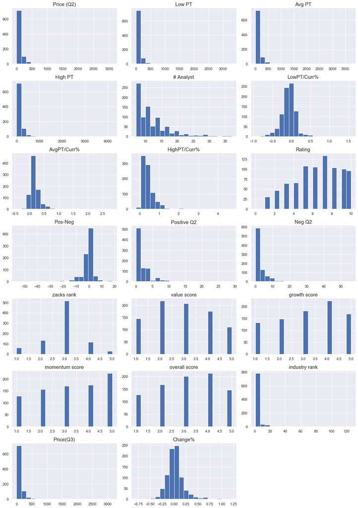

```python
fig = plt.figure(figsize=(15,60))

# extract relevant column names (metrics)
var_list = data.columns[2:]

for n in range(1,len(var_list)+1):

    # generate figures for each metric on each device
    fig.add_subplot(len(var_list), 3, n)
    x_data = data[var_list[n-1]]
    ax = plt.hist(x_data, bins = 20)
    plt.title(var_list[n-1], fontsize=15)
    plt.tight_layout()
```

Everything looks as expected so far for each individual variable, so that is good.

Next, let's move on to pairwise comparison to see the relationship between each feature variable and the dependent variable (price change %)

## EDA - Pairwise Comparison

[figure not shown]

```python
fig = plt.figure(figsize=(15,60))

# extract relevant column names (metrics)
var_list = data.columns[2:]
depn_var = data.iloc[:,-1].values
for n in range(1,len(var_list)):

    # generate figures for each metric on each device
    fig.add_subplot(len(var_list), 3, n)
    x_data = data[var_list[n-1]]
    ax = plt.scatter(x_data, depn_var)
    # Plots best fit line for scatter data
    ax = plt.plot(np.unique(x_data), np.poly1d(np.polyfit(x_data, depn_var, 1))(np.unique(x_data)), color = 'darkred')
    plt.title(var_list[n-1]+' vs '+ 'Price Change%', fontsize=15)
    plt.tight_layout()
```

It appears that TipRank's rating variable and LowPT/CurrPT, AvgPT/CurrPT, and HighPT/CurrPT. We can check Correlation Coefficient to see if these variables do indeed have the highest correlation with the Price Change %

```python
import scipy.stats as stats

df_corr = pd.DataFrame()
pearson = []
spearman = []
feat = []
for i in range(2,len(data.values[0])-1):
    feat.append(data.columns[i])
    pearson.append(stats.pearsonr(data[data.columns[i]], data[data.columns[-1]])[0])
    spearman.append(stats.spearmanr(data[data.columns[i]], data[data.columns[-1]])[0])
df_corr['Feature Variable'] = feat
df_corr['Pearson-R'] = pearson
df_corr['Spearman-Rho'] = spearman
```

```python
df_corr.sort_values(by='Pearson-R')
```

|  | Feature Variable | Pearson-R | Spearman-Rho |
| --- | --- | --- | --- |
| 12 | zacks rank | -0.198719 | -0.186460 |
| 13 | value score | -0.195501 | -0.166508 |
| 16 | overall score | -0.114074 | -0.069727 |
| 11 | Neg Q2 | -0.011587 | -0.040778 |
| 0 | Price (Q2) | 0.015019 | 0.102011 |
| 1 | Low PT | 0.015496 | 0.111019 |
| 14 | growth score | 0.017894 | 0.047529 |
| 9 | Pos-Neg | 0.032676 | 0.051190 |
| 10 | Positive Q2 | 0.034124 | 0.010612 |
| 2 | Avg PT | 0.040013 | 0.141019 |
| 3 | High PT | 0.045868 | 0.137138 |
| 15 | momentum score | 0.075476 | 0.076189 |
| 18 | Price(Q3) | 0.081946 | 0.232884 |
| 4 | # Analyst | 0.104730 | 0.130078 |
| 17 | industry rank | 0.112051 | 0.138205 |
| 5 | LowPT/Curr% | 0.181096 | 0.120748 |
| 8 | Rating | 0.191562 | 0.183625 |
| 7 | HighPT/Curr% | 0.290656 | 0.231755 |
| 6 | AvgPT/Curr% | 0.427874 | 0.304878 |

## EDA - 3 variable Pairwise Comparison

Now there may be interaction effect between variable terms, so we can compare 3 variables at a time to see how they relate to the dependent variable Price Change%

The first column will be comparing using the "TipRanks Ratings" color map  
The second column will be comparing using the "Overall Score" color map  
The third column will be comparing using the "Zacks Rating" color map

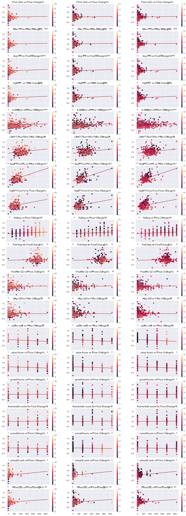

```python
fig = plt.figure(figsize=(20,60))

# extract relevant column names (metrics)
var_list = data.columns[2:]
depn_var = data.iloc[:,-1].values
for n in range(1,len(var_list)):

    # generate figures for each metric on each device
    fig.add_subplot(len(var_list), 3, n*3+1)
    x_data = data[var_list[n-1]]
    ax = plt.scatter(x_data, depn_var, c=data['Rating'])
    plt.colorbar()
    # Plots best fit line for scatter data
    ax = plt.plot(np.unique(x_data), np.poly1d(np.polyfit(x_data, depn_var, 1))(np.unique(x_data)), color = 'darkred')
    plt.title(var_list[n-1]+' vs '+ 'Price Change%', fontsize=15)

        # generate figures for each metric on each device
    fig.add_subplot(len(var_list), 3, n*3+2)
    x_data = data[var_list[n-1]]
    ax = plt.scatter(x_data, depn_var, c=data['overall score'])
    plt.colorbar()
    # Plots best fit line for scatter data
    ax = plt.plot(np.unique(x_data), np.poly1d(np.polyfit(x_data, depn_var, 1))(np.unique(x_data)), color = 'darkred')
    plt.title(var_list[n-1]+' vs '+ 'Price Change%', fontsize=15)

            # generate figures for each metric on each device
    fig.add_subplot(len(var_list), 3, n*3+3)
    x_data = data[var_list[n-1]]
    ax = plt.scatter(x_data, depn_var, c=data['zacks rank'])
    plt.colorbar()
    # Plots best fit line for scatter data
    ax = plt.plot(np.unique(x_data), np.poly1d(np.polyfit(x_data, depn_var, 1))(np.unique(x_data)), color = 'darkred')
    plt.title(var_list[n-1]+' vs '+ 'Price Change%', fontsize=15)
```

Lots going on here as well, and lots of interesting patterns but let's do the regression to see what type of model we will generate first.

## Machine Learning

First we need to split the data into test and training sets. We then need to scale each numerical variable first since they are all different values. We also don't need Q3 price and Q2 stock prices and company ticker/name in the dataset

```python
data_copy = data.copy()
```

```python
data_copy.drop(['Price (Q2)', 'Price(Q3)', 'Ticker', 'Company Name'], inplace = True, axis = 1)
```

```python
data_copy
```

|  | Low PT | Avg PT | High PT | # Analyst | LowPT/Curr% | AvgPT/Curr% | HighPT/Curr% | Rating | Pos-Neg | Positive Q2 | Neg Q2 | zacks rank | value score | growth score | momentum score | overall score | industry rank | Change% |
| --- | --- | --- | --- | --- | --- | --- | --- | --- | --- | --- | --- | --- | --- | --- | --- | --- | --- | --- |
| 0 | 3.0 | 6.86 | 10.0 | 8 | -0.755102 | -0.440000 | -0.183673 | 4 | -28 | 6.0 | 34.0 | 3.0 | 1 | 3 | 4 | 2 | 1.3 | -0.7951 |
| 1 | 3.0 | 3.50 | 4.5 | 8 | -0.238579 | -0.111675 | 0.142132 | 3 | -2 | 0.0 | 2.0 | 2.0 | 5 | 1 | 5 | 4 | 2.0 | -0.5964 |
| 2 | 1.0 | 1.63 | 2.5 | 9 | -0.572650 | -0.303419 | 0.068376 | 2 | -8 | 0.0 | 8.0 | 3.0 | 5 | 3 | 3 | 5 | 1.2 | -0.5841 |
| 3 | 8.0 | 16.08 | 25.0 | 13 | -0.528024 | -0.051327 | 0.474926 | 1 | -2 | 0.0 | 2.0 | 3.0 | 4 | 1 | 2 | 2 | 2.0 | -0.4094 |
| 4 | 77.0 | 111.13 | 188.0 | 24 | -0.396457 | -0.128939 | 0.473585 | 7 | -4 | 1.0 | 5.0 | 4.0 | 2 | 5 | 4 | 4 | 1.3 | -0.4037 |
| ... | ... | ... | ... | ... | ... | ... | ... | ... | ... | ... | ... | ... | ... | ... | ... | ... | ... | ... |
| 849 | 40.0 | 68.25 | 88.0 | 9 | -0.073216 | 0.581325 | 1.038925 | 7 | -4 | 0.0 | 4.0 | 3.0 | 1 | 3 | 5 | 3 | 1.3 | 0.9701 |
| 850 | 180.0 | 210.86 | 250.0 | 8 | 0.516173 | 0.776112 | 1.105795 | 7 | 2 | 4.0 | 2.0 | 3.0 | 2 | 4 | 4 | 3 | 1.4 | 1.0056 |
| 851 | 22.0 | 56.13 | 80.0 | 13 | -0.387698 | 0.562204 | 1.226552 | 8 | -1 | 0.0 | 1.0 | 2.0 | 2 | 1 | 5 | 1 | 2.5 | 1.0234 |
| 852 | 9.0 | 13.43 | 20.0 | 8 | 1.564103 | 2.826211 | 4.698006 | 8 | -13 | 10.0 | 23.0 | 3.0 | 1 | 2 | 3 | 1 | 1.2 | 1.0627 |
| 853 | 15.0 | 34.25 | 50.0 | 10 | -0.038462 | 1.195513 | 2.205128 | 4 | 0 | 0.0 | 0.0 | 3.0 | 1 | 2 | 3 | 1 | 1.3 | 1.2083 |

854 rows × 18 columns

```python
from sklearn.preprocessing import StandardScaler
from sklearn.model_selection import train_test_split
```

```python
x = data_copy.iloc[:,:-1].values
y = data_copy.iloc[:,-1].values

x_train, x_test, y_train, y_test = train_test_split(x, y, test_size=0.1, random_state=10, shuffle = True)

ss = StandardScaler()
scaled_x_train = ss.fit_transform(x_train)
scaled_x_test = ss.transform(x_test)
```

```python
from sklearn.linear_model import LinearRegression
model = LinearRegression(n_jobs = -1)
model.fit(scaled_x_train, y_train)
```

```
LinearRegression(n_jobs=-1)
```

```python
# R^2 score
model.score(scaled_x_train, y_train)
```

```
0.31997829800459265
```

```python
#Perform 5-fold Cross Validation to see better statistics
from sklearn.model_selection import cross_val_score
scores = cross_val_score(model, scaled_x_train, y_train, scoring='r2', cv=5)
print('R2 scores:', scores)
print('Mean:',scores.mean(), '\nStandard Deviation:', scores.std())
```

```
R2 scores: [0.1782911  0.45263487 0.30639027 0.20100533 0.14789635]
Mean: 0.2572435838645507
Standard Deviation: 0.11130696677293798
```

Overall, the R^2 score is poor and there is still much optimization that can be done to the model.

```python
# Linear model variable coefficients
df = pd.DataFrame()
df['Feature Variables'] = data_copy.columns[0:-1]
df['Model Coeff'] = model.coef_
df.sort_values(by=['Model Coeff'])
```

[output not shown]

```python
# We can also use statsmodel library to check on linear regression statistics
```

```python
import statsmodels.api as sm
data_constant = sm.add_constant(scaled_x_train, prepend=False)
# Fit and summarize OLS model
mod = sm.OLS(y_train, data_constant)
res = mod.fit()
print(res.summary())
```

```
                            OLS Regression Results
==============================================================================
Dep. Variable:                      y   R-squared:                       0.316
Model:                            OLS   Adj. R-squared:                  0.302
Method:                 Least Squares   F-statistic:                     21.70
Date:                Fri, 02 Oct 2020   Prob (F-statistic):           8.05e-52
Time:                        16:36:19   Log-Likelihood:                 331.94
No. Observations:                 768   AIC:                            -629.9
Df Residuals:                     751   BIC:                            -550.9
Df Model:                          16
Covariance Type:            nonrobust
==============================================================================
                 coef    std err          t      P>|t|      [0.025      0.975]
------------------------------------------------------------------------------
x1             0.1002      0.055      1.811      0.071      -0.008       0.209
x2            -0.4765      0.174     -2.740      0.006      -0.818      -0.135
x3             0.3743      0.133      2.808      0.005       0.113       0.636
x4             0.0067      0.007      1.012      0.312      -0.006       0.020
x5            -0.0745      0.011     -6.497      0.000      -0.097      -0.052
x6             0.2383      0.021     11.447      0.000       0.197       0.279
x7            -0.1339      0.017     -7.759      0.000      -0.168      -0.100
x8             0.0135      0.006      2.169      0.030       0.001       0.026
x9             0.0072      0.003      2.061      0.040       0.000       0.014
x10           -0.0010      0.005     -0.209      0.835      -0.011       0.009
x11           -0.0077      0.003     -2.287      0.022      -0.014      -0.001
x12           -0.0152      0.006     -2.436      0.015      -0.028      -0.003
x13            0.0026      0.011      0.229      0.819      -0.020       0.025
x14            0.0239      0.012      1.938      0.053      -0.000       0.048
x15            0.0209      0.008      2.723      0.007       0.006       0.036
x16           -0.0401      0.017     -2.376      0.018      -0.073      -0.007
x17            0.0065      0.006      1.055      0.292      -0.006       0.019
const          0.0269      0.006      4.688      0.000       0.016       0.038
==============================================================================
Omnibus:                      106.969   Durbin-Watson:                   1.918
Prob(Omnibus):                  0.000   Jarque-Bera (JB):              444.978
Skew:                           0.577   Prob(JB):                     2.37e-97
Kurtosis:                       6.546   Cond. No.                     7.77e+15
==============================================================================

Warnings:
[1] Standard Errors assume that the covariance matrix of the errors is correctly specified.
[2] The smallest eigenvalue is 4.36e-29. This might indicate that there are
strong multicollinearity problems or that the design matrix is singular.
```

From the summary statistics, there appears to be some multi-collinearity which is affecting the model such as the high p-value for variable x10 and x13

An alternative is to use Random Forest Regressor since that machine learning algorithm performs self-feature selection and not use all of the feature variables in its model.

## Alternative Machine Learning Regression Models

Let's try Random Forest Regression now since it usually performs better than Linear Regression algorithm

```python
from sklearn.ensemble import RandomForestRegressor
```

```python
model = RandomForestRegressor(n_estimators = 100, n_jobs = -1, random_state = 10)
model.fit(scaled_x_train, y_train)
```

```
RandomForestRegressor(n_jobs=-1, random_state=10)
```

```python
# Random Forest Regressor Feature Importance Ranking
df = pd.DataFrame()
df['Feature Variables'] = data_copy.columns[0:-1]
df['Feature Importance'] = model.feature_importances_
df.sort_values(by='Feature Importance', ascending = False)
```

|  | Feature Variables | Feature Importance |
| --- | --- | --- |
| 5 | AvgPT/Curr% | 0.265468 |
| 4 | LowPT/Curr% | 0.149375 |
| 6 | HighPT/Curr% | 0.106430 |
| 16 | industry rank | 0.052843 |
| 1 | Avg PT | 0.048195 |
| 7 | Rating | 0.044512 |
| 0 | Low PT | 0.043868 |
| 3 | # Analyst | 0.040952 |
| 2 | High PT | 0.037709 |
| 11 | zacks rank | 0.034616 |
| 12 | value score | 0.034373 |
| 8 | Pos-Neg | 0.028463 |
| 10 | Neg Q2 | 0.027608 |
| 14 | momentum score | 0.025928 |
| 15 | overall score | 0.021035 |
| 13 | growth score | 0.020854 |
| 9 | Positive Q2 | 0.017772 |

```python
#Perform 5-fold Cross Validation to see better statistics
from sklearn.model_selection import cross_val_score
scores = cross_val_score(model, scaled_x_train, y_train, scoring='r2', cv=5)
print('R2 scores:', scores)
print('Mean:',scores.mean(), '\nStandard Deviation:', scores.std())
```

```
R2 scores: [0.15673452 0.33619531 0.09763067 0.19011823 0.14668024]
Mean: 0.18547179457297852
Standard Deviation: 0.08097635035921719
```

Much optimization and feature engineering can still be done to improve the model.

For example, stocks can also be separated by industry such as comparison for all tech stocks, all finance stocks, etc...

Another simple way to improve the model accuracy (high R^2 score) is to interact Zack's Rank and TipRank's Rating scores, if both sources give a high score to a specific stock, then most likely it will have a high potential for positive growth

```python
data_copy['zacks rank'] = data_copy['zacks rank'].map({1.0: 5, 2.0:4, 3.0:3, 4.0:2, 5.0:1})
```

```python
data_copy['TipRanks+Zacks_Score'] = data_copy['Rating']*data_copy['zacks rank']
# Have to rearrange dependent variable back to last column to make processing easier
temp = data_copy['Change%']
data_copy.drop(['Change%'], inplace = True, axis = 1)
data_copy['Change%'] = temp
```

```python
data_copy
```

|  | Low PT | Avg PT | High PT | # Analyst | LowPT/Curr% | AvgPT/Curr% | HighPT/Curr% | Rating | Pos-Neg | Positive Q2 | Neg Q2 | zacks rank | value score | growth score | momentum score | overall score | industry rank | TipRanks+Zacks_Score | Change% |
| --- | --- | --- | --- | --- | --- | --- | --- | --- | --- | --- | --- | --- | --- | --- | --- | --- | --- | --- | --- |
| 0 | 3.0 | 6.86 | 10.0 | 8 | -0.755102 | -0.440000 | -0.183673 | 4 | -28 | 6.0 | 34.0 | 3 | 1 | 3 | 4 | 2 | 1.3 | 12 | -0.7951 |
| 1 | 3.0 | 3.50 | 4.5 | 8 | -0.238579 | -0.111675 | 0.142132 | 3 | -2 | 0.0 | 2.0 | 4 | 5 | 1 | 5 | 4 | 2.0 | 12 | -0.5964 |
| 2 | 1.0 | 1.63 | 2.5 | 9 | -0.572650 | -0.303419 | 0.068376 | 2 | -8 | 0.0 | 8.0 | 3 | 5 | 3 | 3 | 5 | 1.2 | 6 | -0.5841 |
| 3 | 8.0 | 16.08 | 25.0 | 13 | -0.528024 | -0.051327 | 0.474926 | 1 | -2 | 0.0 | 2.0 | 3 | 4 | 1 | 2 | 2 | 2.0 | 3 | -0.4094 |
| 4 | 77.0 | 111.13 | 188.0 | 24 | -0.396457 | -0.128939 | 0.473585 | 7 | -4 | 1.0 | 5.0 | 2 | 2 | 5 | 4 | 4 | 1.3 | 14 | -0.4037 |
| ... | ... | ... | ... | ... | ... | ... | ... | ... | ... | ... | ... | ... | ... | ... | ... | ... | ... | ... | ... |
| 849 | 40.0 | 68.25 | 88.0 | 9 | -0.073216 | 0.581325 | 1.038925 | 7 | -4 | 0.0 | 4.0 | 3 | 1 | 3 | 5 | 3 | 1.3 | 21 | 0.9701 |
| 850 | 180.0 | 210.86 | 250.0 | 8 | 0.516173 | 0.776112 | 1.105795 | 7 | 2 | 4.0 | 2.0 | 3 | 2 | 4 | 4 | 3 | 1.4 | 21 | 1.0056 |
| 851 | 22.0 | 56.13 | 80.0 | 13 | -0.387698 | 0.562204 | 1.226552 | 8 | -1 | 0.0 | 1.0 | 4 | 2 | 1 | 5 | 1 | 2.5 | 32 | 1.0234 |
| 852 | 9.0 | 13.43 | 20.0 | 8 | 1.564103 | 2.826211 | 4.698006 | 8 | -13 | 10.0 | 23.0 | 3 | 1 | 2 | 3 | 1 | 1.2 | 24 | 1.0627 |
| 853 | 15.0 | 34.25 | 50.0 | 10 | -0.038462 | 1.195513 | 2.205128 | 4 | 0 | 0.0 | 0.0 | 3 | 1 | 2 | 3 | 1 | 1.3 | 12 | 1.2083 |

854 rows × 19 columns

Now time to retest the linear model and see the R^2 score

```python
x = data_copy.iloc[:,:-1].values
y = data_copy.iloc[:,-1].values

x_train, x_test, y_train, y_test = train_test_split(x, y, test_size=0.1, random_state=10, shuffle = True)

ss = StandardScaler()
scaled_x_train = ss.fit_transform(x_train)
scaled_x_test = ss.transform(x_test)
```

```python
data_copy.drop(['TipRanks+Zacks_Score'], inplace = True, axis = 1)
```

```python
from sklearn.linear_model import LinearRegression
model = LinearRegression(n_jobs = -1)
model.fit(scaled_x_train, y_train)
```

```
LinearRegression(n_jobs=-1)
```

```python
#Perform 5-fold Cross Validation to see better statistics
from sklearn.model_selection import cross_val_score
scores = cross_val_score(model, scaled_x_train, y_train, scoring='r2', cv=5)
print('R2 scores:', scores)
print('Mean:',scores.mean(), '\nStandard Deviation:', scores.std())
```

[output not shown]

```python
copy_xtrain = scaled_x_train.copy()
```

```python
x_test = []
best_columns = []
max_score = 0
best_col = -1

# Backwards eliminate 3 columns first
for j in range(5):
    if best_col == old_best_col:
        break
    old_best_col = best_col
    for i in range(len(copy_xtrain[0])):

        new_table = np.delete(copy_xtrain, i, axis = 1)
        model = LinearRegression(n_jobs = -1)
        model.fit(new_table, y_train)
        scores = cross_val_score(model, new_table, y_train, scoring='r2', cv=5)
        curr_score = scores.mean()

        if curr_score > max_score:
            best_col = i
            max_score = curr_score
    if best_col == old_best_col:
        continue
    else:
        copy_xtrain = np.delete(copy_xtrain, best_col, axis = 1)

        print('Column removed = ', best_col)
```

```
Column removed =  0
Column removed =  10
Column removed =  12
```

```python
# The three columns removed are
print(data_copy.iloc[:,:-1].columns[0])
print(data_copy.iloc[:,:-1].columns[10])
print(data_copy.iloc[:,:-1].columns[12])
```

```
Low PT
Neg Q2
value score
```

Now we can test the new dataset with 3 columns removed from backwards feature selection

```python
scores = cross_val_score(model, copy_xtrain, y_train, scoring='r2', cv=5)
print('R2 scores:', scores)
print('Mean:',scores.mean(), '\nStandard Deviation:', scores.std())
```

```
R2 scores: [0.23853127 0.45007383 0.28695765 0.20532859 0.15127079]
Mean: 0.2664324250497714
Standard Deviation: 0.10190172497144995
```

As observed, the mean R^2 score jumped from 0.257 to 0.266. Although this is still far from great, we have shown that the model can constantly be improved using data mining techniques.

## Conclusion

In the end, remember here that the data is not realistic since Q3 has not ended yet and it is actually better to use Q4 or 2021 Q1 price change% data as the dependent variable.

Garbage dataset will produce a garbage model. Nothing we do will be able to push the model to above 0.50 R^2 score if we are using September stock prices as the dependent variable in this dataset.

The goal for this demo is not to build the perfect regression model for the dataset collected.

The goal of this project however is just to show that webscraping and document sentiment analys can collect useful data for stock market long-term investment predictions.